# R Notebook serie de tiempo caso ETA’s para cantidad de enfermos

Andrea Catalán, Diego Carroza

25/06/2024

Al principio, en la propuesta del proyecto planteamos que existe un factor estacional en la cantidad de enfermos por ETA durante un año, considerando que es probable ver un aumento de la cantidad de ellos en periodos como vacaciones de verano, pascua y fiestas patrias.

Comenzamos explorando los datos y limpiando la BD, observando valores aberrantes y casos no confirmados. Luego, al poseer una BD con tantos atributos fuimos cambiando el enfoque tratando de ver causas de las enfermedades, separación por grupos etarios, análisis por regiones, alimentos causantes, cantidad de muertes, tasa de letalidad, cantidad de enfermos, hospitalizados y así mezclando variables y cambiando el enfoque a estimación de Disease Burden y severidad.

Finalmente, para aterrizar el proyecto a lo relevante del curso y en virtud del tiempo que se le puede dedicar a ser algo semestral, combinado con otros cursos, es que se volvió al enfoque inicial. En base a lo ya analizado anteriormente, se corroboró el aspecto estacional de la cantidad de enfermos por brotes de ETA , por lo que se decidió hacer pronóstico de esto.

El objetivo de esta entrega es aplicar serie de tiempo para hacer pronostico de la cantidad de enfermos en base a la data que tenemos.

Instalar y cargar paquetes

1. Tools -> Install Packages
2. Cargar paquetes

```r
library(tidyverse)
library(readxl)
library(dplyr)
library(ggplot2)
library(plotly)
library(lubridate)
library(forecast)
library(tseries)
library(TSA)
library(urca)
library(ggplot2)
library(dplyr)
library(stats)
library(seasonal)
library(tseries)
```

Importar datos y guardar en variable

```r
ETA <- read_excel("BaseETA.xlsx")
```

| N° Brote ETA | Año estadistico | Semana estadistica | Fecha de notificación | Fecha de Ingestión | Fecha Primeros Síntomas | Periodo de Incubación Días | Duración Brote Días | Región de consumo | Expuestos | Enfermos | Fallecidos | Tasa Ataque | Tasa Letalidad | Total de Hospitalizados | Total sin atención | Total ambulatorios | Total enfermos <1 | Total enfermos 1-4 | Total enfermos 5-14 | Total enfermos 15-44 | Total enfermos 45-64 | Total enfermos >65 | Grupo Alimento Sospechoso | Alimento Sospechoso | Sub agrupación alimento sospechoso | Grandes grupos alimentos sospechoso | Local de elaboración | Local consumo | Glosa_contaminación | … |
| --- | --- | --- | --- | --- | --- | --- | --- | --- | --- | --- | --- | --- | --- | --- | --- | --- | --- | --- | --- | --- | --- | --- | --- | --- | --- | --- | --- | --- | --- | --- |
| MET20110841 | 2011 | 1 | 2011-01-03 | 2011-01-01 | 2011-01-01 | 0 | 1 | Metropolitana de Santiago | 5 | 5 | 0 | 80.00 | 0 | 0 | 0 | 5 | 1 | 0 | 0 | 3 | 1 | 0 | Huevos Y Ovoproductos | Huevos Frescos | Huevos | Origen animal | Lugar Autopreparación | Hogar | Contaminación cruzada por alimento crudo, manos del manipulador, guantes, utensilios, superficies, ambiente | … |
| MET20110779 | 2011 | 1 | 2011-01-07 | 2011-01-01 | 2011-01-02 | 1 | 1 | Metropolitana de Santiago | 8 | 3 | 0 | 37.50 | 0 | 0 | 0 | 3 | 0 | 0 | 0 | 2 | 1 | 0 | Pescados Y Productos De La Pesca | Pescados y mariscos crudos congelados | Pescados y mariscos crudos | Productos de la pesca | Lugar Autopreparación | Hogar | Obtención, ingestión, de productos crudos o ingredientes contaminados por patógenos provenientes de animales o del medio ambiente | … |
| ARI20110002 | 2011 | 2 | 2011-01-24 | 2011-01-16 | 2011-01-17 | 0 | 0 | De Arica y Parinacota | 16 | 10 | 0 | 62.50 | 0 | 2 | 3 | 5 | 0 | 0 | 4 | 5 | 1 | 0 | Huevos Y Ovoproductos | Mayonesa y otras salsas a base de huevo | Huevos | Origen animal | Lugar Autopreparación | Hogar | NA | … |
| VAL20110062 | 2011 | 1 | 2011-01-03 | 2010-12-31 | 2011-01-01 | 1 | 0 | De Valparaíso | 9 | 3 | 0 | 33.33 | 0 | 0 | 0 | 3 | 0 | 0 | 0 | 2 | 1 | 0 | Huevos Y Ovoproductos | Mayonesa y otras salsas a base de huevo | Huevos | Origen animal | Lugar Autopreparación | Hogar | Obtención, ingestión, de productos crudos o ingredientes contaminados por patógenos provenientes de animales o del medio ambiente | … |
| MET20110780 | 2011 | 1 | 2011-01-06 | 2011-01-03 | 2011-01-03 | 0 | 1 | Metropolitana de Santiago | 2 | 2 | 0 | 100.00 | 0 | 0 | 0 | 2 | 0 | 0 | 0 | 2 | 0 | 0 | No Identificado | No Identificado | Sin identificar | Sin identificar | Lugar Autopreparación | Hogar | Otra fuente de contaminación, no descrita arriba | … |
| ARI20110003 | 2011 | 1 | 2011-01-04 | 2011-01-01 | 2011-01-02 | 0 | 0 | De Arica y Parinacota | 11 | 9 | 0 | 81.82 | 0 | 0 | 4 | 5 | 0 | 0 | 0 | 6 | 2 | 1 | NA | NA | NA | NA | NA | NA | NA | … |

Filtrar ETA sin N/A en tasa de ataque

```r
ETA <- filter(ETA,!is.na(ETA$`Tasa Ataque`))
ETA <- filter(ETA,ETA$`Tasa Ataque`<=100)
```

Filtro para dejar solo los casos confirmados

```r
ETA_CasosConfirmados <- filter(ETA, ETA$`Conclusión del brote`=="Realizada, se confirma")
head(ETA_CasosConfirmados)
```

| N° Brote ETA | Año estadistico | Semana estadistica | Fecha de notificación | Fecha de Ingestión | Fecha Primeros Síntomas | Periodo de Incubación Días | Duración Brote Días | Región de consumo | Expuestos | Enfermos | Fallecidos | Tasa Ataque | Tasa Letalidad | Total de Hospitalizados | Total sin atención | Total ambulatorios | Total enfermos <1 | Total enfermos 1-4 | Total enfermos 5-14 | Total enfermos 15-44 | Total enfermos 45-64 | Total enfermos >65 | Grupo Alimento Sospechoso | Alimento Sospechoso | Sub agrupación alimento sospechoso | Grandes grupos alimentos sospechoso | Local de elaboración | Local consumo | Glosa_contaminación | … |
| --- | --- | --- | --- | --- | --- | --- | --- | --- | --- | --- | --- | --- | --- | --- | --- | --- | --- | --- | --- | --- | --- | --- | --- | --- | --- | --- | --- | --- | --- | --- |
| ARI20110002 | 2011 | 2 | 2011-01-24 | 2011-01-16 | 2011-01-17 | 0 | 0 | De Arica y Parinacota | 16 | 10 | 0 | 62.50 | 0 | 2 | 3 | 5 | 0 | 0 | 4 | 5 | 1 | 0 | Huevos Y Ovoproductos | Mayonesa y otras salsas a base de huevo | Huevos | Origen animal | Lugar Autopreparación | Hogar | NA | … |
| MET20110559 | 2011 | 2 | 2011-01-21 | 2011-01-09 | 2011-01-13 | 4 | 1 | Metropolitana de Santiago | 2 | 2 | 0 | 100.00 | 0 | 0 | 0 | 2 | 0 | 2 | 0 | 0 | 0 | 0 | Carnes Y Productos Carneos (Incluidas Carnes De Aves Y De Caza) | Carne de Aves | Carne de ave | Origen animal | Lugar Autopreparación | Hogar | Contaminación cruzada por alimento crudo, manos del manipulador, guantes, utensilios, superficies, ambiente | … |
| BIO20110168 | 2011 | 2 | 2011-01-10 | 2011-01-08 | 2011-01-09 | 1 | 0 | Del Bíobío | 6 | 6 | 0 | 100.00 | 0 | 0 | 0 | 6 | 0 | 0 | 3 | 3 | 0 | 0 | Pescados Y Productos De La Pesca | Moluscos Bivalvos, frescos | Moluscos | Productos de la pesca | Lugar No Habilitado O Sólo Expendio | Hogar | Obtención, ingestión, de productos crudos o ingredientes contaminados por patógenos provenientes de animales o del medio ambiente | … |
| TAR20110043 | 2011 | 2 | 2011-01-12 | 2011-01-12 | 2011-01-12 | 0 | 0 | De Tarapacá | 24 | 5 | 0 | 20.83 | 0 | 0 | 0 | 5 | 0 | 0 | 0 | 5 | 0 | 0 | Comidas Y Platos Preparados | Comidas y platos mixtos con ingrediente(s) crudo(s) y/o cocido(s), incluidos emparedados | Comidas y platos preparados | Otros alimentos | NA | NA | Contaminación cruzada por alimento crudo, manos del manipulador, guantes, utensilios, superficies, ambiente | … |
| TAR20110017 | 2011 | 2 | 2011-01-12 | 2011-01-11 | 2011-01-12 | 1 | 0 | De Tarapacá | 6 | 6 | 0 | 100.00 | 0 | 0 | 0 | 6 | 0 | 0 | 0 | 5 | 1 | 0 | Huevos Y Ovoproductos | Otro producto en base huevo y ovoproductos | Huevos | Origen animal | NA | NA | Obtención, ingestión, de productos crudos o ingredientes contaminados por patógenos provenientes de animales o del medio ambiente | … |
| ARA20110011 | 2011 | 2 | 2011-01-11 | 2011-01-11 | 2011-01-11 | 0 | 0 | De La Araucanía | 11 | 11 | 0 | 100.00 | 0 | 0 | 0 | 11 | 0 | 11 | 0 | 0 | 0 | 0 | No Identificado | No Identificado | Sin identificar | Sin identificar | NA | NA | NA | … |

Filtro casos atípicos

```r
ETA_CasosConfirmados <- filter(ETA_CasosConfirmados, ETA_CasosConfirmados$Enfermos!=5470)
ETA_CasosConfirmados <- filter(ETA_CasosConfirmados, ETA_CasosConfirmados$Enfermos!=517)
head(ETA_CasosConfirmados)
```

| N° Brote ETA | Año estadistico | Semana estadistica | Fecha de notificación | Fecha de Ingestión | Fecha Primeros Síntomas | Periodo de Incubación Días | Duración Brote Días | Región de consumo | Expuestos | Enfermos | Fallecidos | Tasa Ataque | Tasa Letalidad | Total de Hospitalizados | Total sin atención | Total ambulatorios | Total enfermos <1 | Total enfermos 1-4 | Total enfermos 5-14 | Total enfermos 15-44 | Total enfermos 45-64 | Total enfermos >65 | Grupo Alimento Sospechoso | Alimento Sospechoso | Sub agrupación alimento sospechoso | Grandes grupos alimentos sospechoso | Local de elaboración | Local consumo | Glosa_contaminación | … |
| --- | --- | --- | --- | --- | --- | --- | --- | --- | --- | --- | --- | --- | --- | --- | --- | --- | --- | --- | --- | --- | --- | --- | --- | --- | --- | --- | --- | --- | --- | --- |
| ARI20110002 | 2011 | 2 | 2011-01-24 | 2011-01-16 | 2011-01-17 | 0 | 0 | De Arica y Parinacota | 16 | 10 | 0 | 62.50 | 0 | 2 | 3 | 5 | 0 | 0 | 4 | 5 | 1 | 0 | Huevos Y Ovoproductos | Mayonesa y otras salsas a base de huevo | Huevos | Origen animal | Lugar Autopreparación | Hogar | NA | … |
| MET20110559 | 2011 | 2 | 2011-01-21 | 2011-01-09 | 2011-01-13 | 4 | 1 | Metropolitana de Santiago | 2 | 2 | 0 | 100.00 | 0 | 0 | 0 | 2 | 0 | 2 | 0 | 0 | 0 | 0 | Carnes Y Productos Carneos (Incluidas Carnes De Aves Y De Caza) | Carne de Aves | Carne de ave | Origen animal | Lugar Autopreparación | Hogar | Contaminación cruzada por alimento crudo, manos del manipulador, guantes, utensilios, superficies, ambiente | … |
| BIO20110168 | 2011 | 2 | 2011-01-10 | 2011-01-08 | 2011-01-09 | 1 | 0 | Del Bíobío | 6 | 6 | 0 | 100.00 | 0 | 0 | 0 | 6 | 0 | 0 | 3 | 3 | 0 | 0 | Pescados Y Productos De La Pesca | Moluscos Bivalvos, frescos | Moluscos | Productos de la pesca | Lugar No Habilitado O Sólo Expendio | Hogar | Obtención, ingestión, de productos crudos o ingredientes contaminados por patógenos provenientes de animales o del medio ambiente | … |
| TAR20110043 | 2011 | 2 | 2011-01-12 | 2011-01-12 | 2011-01-12 | 0 | 0 | De Tarapacá | 24 | 5 | 0 | 20.83 | 0 | 0 | 0 | 5 | 0 | 0 | 0 | 5 | 0 | 0 | Comidas Y Platos Preparados | Comidas y platos mixtos con ingrediente(s) crudo(s) y/o cocido(s), incluidos emparedados | Comidas y platos preparados | Otros alimentos | NA | NA | Contaminación cruzada por alimento crudo, manos del manipulador, guantes, utensilios, superficies, ambiente | … |
| TAR20110017 | 2011 | 2 | 2011-01-12 | 2011-01-11 | 2011-01-12 | 1 | 0 | De Tarapacá | 6 | 6 | 0 | 100.00 | 0 | 0 | 0 | 6 | 0 | 0 | 0 | 5 | 1 | 0 | Huevos Y Ovoproductos | Otro producto en base huevo y ovoproductos | Huevos | Origen animal | NA | NA | Obtención, ingestión, de productos crudos o ingredientes contaminados por patógenos provenientes de animales o del medio ambiente | … |
| ARA20110011 | 2011 | 2 | 2011-01-11 | 2011-01-11 | 2011-01-11 | 0 | 0 | De La Araucanía | 11 | 11 | 0 | 100.00 | 0 | 0 | 0 | 11 | 0 | 11 | 0 | 0 | 0 | 0 | No Identificado | No Identificado | Sin identificar | Sin identificar | NA | NA | NA | … |

Seleccionar columnas con fecha y número de enfermos

```r
ETA_Enfermos <- select(ETA_CasosConfirmados,4,11)
head(ETA_Enfermos)
```

| Fecha de notificación | Enfermos |
| --- | --- |
| 2011-01-24 | 10 |
| 2011-01-21 | 2 |
| 2011-01-10 | 6 |
| 2011-01-12 | 5 |
| 2011-01-12 | 6 |
| 2011-01-11 | 11 |

Renombrar columnas

```r
colnames(ETA_Enfermos)
```

```
[1] "Fecha de notificación" "Enfermos"
```

```r
colnames(ETA_Enfermos)[1] <- "Fecha"
colnames(ETA_Enfermos)[2] <- "Enfermos"
```

Agrupar número de enfermos por fecha (juntar todos los enfermos de una misma fecha)

```r
ETA_Enfermos <- ETA_Enfermos %>%
  group_by(Fecha) %>%
  summarise(Enfermos=sum(Enfermos))
head(ETA_Enfermos)
```

| Fecha | Enfermos |
| --- | --- |
| 2011-01-10 | 6 |
| 2011-01-11 | 11 |
| 2011-01-12 | 11 |
| 2011-01-14 | 2 |
| 2011-01-17 | 2 |
| 2011-01-18 | 2 |

Crear columna que indique a que mes correlativo corresponde  
Ej: Enero a Diciembre 2011, va de los meses 1 a 12, Enero a Diciembre 2012, va de los meses 13 a 24, así sucesivamente.

```r
ETA_Enfermos$Mes_Correlativo <- as.integer(format(ETA_Enfermos$Fecha, "%m")) + 12 * (as.integer(format(ETA_Enfermos$Fecha, "%Y")) - 2011)
```

Agrupar número de enfermos por mes correlativo

```r
ETA_Enfermos <- ETA_Enfermos %>%
  group_by(Mes_Correlativo) %>%
  summarise(Enfermos=sum(Enfermos))
head(ETA_Enfermos)
```

| Mes_Correlativo | Enfermos |
| --- | --- |
| 1 | 75 |
| 2 | 83 |
| 3 | 335 |
| 4 | 198 |
| 5 | 408 |
| 6 | 169 |

Convertir a Serie de Tiempo

```r
Enfermos=select(ETA_Enfermos,2)
head(Enfermos)
```

| Enfermos |
| --- |
| 75 |
| 83 |
| 335 |
| 198 |
| 408 |
| 169 |

```r
SerieEnfermos=ts(Enfermos$Enfermos,freq=12,start=c(2011,1))
```

Graficar serie de tiempo

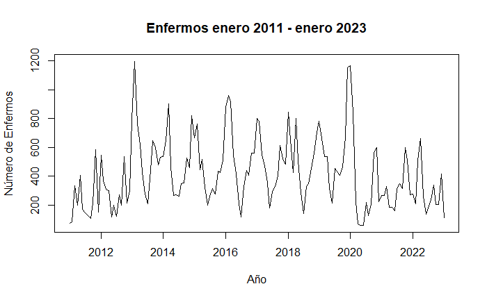

```r
plot(SerieEnfermos, main="Enfermos enero 2011 - enero 2023",xlab="Año",ylab="Número de Enfermos")
```

```r
Descom<- decompose(SerieEnfermos)
par(mfrow = c(2, 2)) #Se utiliza para dividir la ventana gráfica en una matriz de 2 filas y 2 columnas
plot(Descom$x, main = "Enfermos enero 2011 - enero 2023", col = "black", ylab = "Número de Enfermos", xlab = "Año")
plot(Descom$trend, main = "Tendencia", col = "blue", ylab = "Número de Enfermos", xlab = "Año")
```

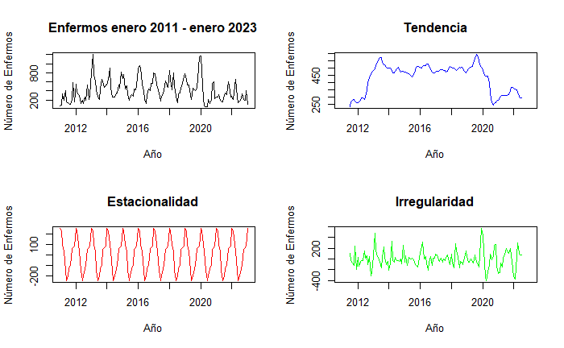

```r
plot(Descom$seasonal, main = "Estacionalidad", col = "red", ylab = "Número de Enfermos", xlab = "Año")
plot(Descom$random, main = "Irregularidad", col = "green", ylab = "Número de Enfermos", xlab = "Año")
```

Aplicación modelo Arima

1. Validar estacionalidad de la serie (Se dice que una serie es estacionaria cuando su media, varianza y autocovarianza son invariantes en el tiempo)
2. Test de Dickey Fuller
3. H0: Serie No estacionaria: Hay raiz unitaria H1: Serie Estacionaria: No hay raiz unitaria

```r
adf.test(SerieEnfermos)
```

```
    Augmented Dickey-Fuller Test

data:  SerieEnfermos
Dickey-Fuller = -5.0521, Lag order = 5, p-value = 0.01
alternative hypothesis: stationary
```

Como el p-value = 0.01 < 0.05 entonces hay evidencia suficiente para rechazar la hipótesis nula (H0), esto implica que la serie temporal es estacionaria

La función de autocorrelación (ACF): mide la correlación entre una serie de tiempo y sus valores retrasados. Con ello podemos obtener q, el cual es el orden componente de media móvil, el cual utiliza errores pasados para predecir errores futuros

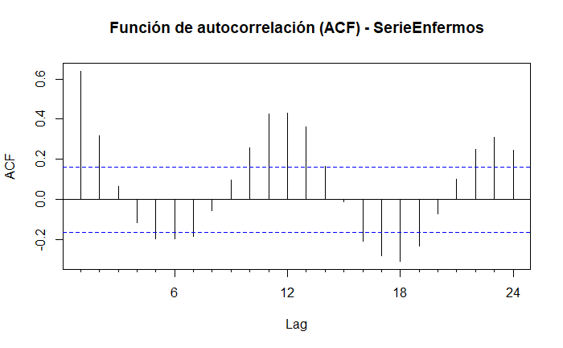

```r
Acf(SerieEnfermos, main='Función de autocorrelación (ACF) - SerieEnfermos')
```

Función de autocorrelación parcial (PACF) que mide la correlación entre una serie de tiempo y sus valores retrasados

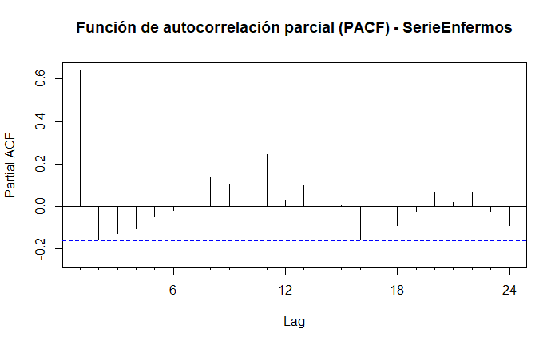

```r
Pacf(SerieEnfermos, main='Función de autocorrelación parcial (PACF) - SerieEnfermos')
```

Detectar cúal es el mejor modelo a utilizar con Arima

```r
auto.arima(SerieEnfermos)
```

```
Series: SerieEnfermos
ARIMA(1,0,0)(1,0,1)[12] with non-zero mean

Coefficients:
         ar1    sar1     sma1      mean
      0.5960  0.7949  -0.6282  391.0569
s.e.  0.0721  0.1672   0.2255   55.8897

sigma^2 = 31209:  log likelihood = -954.91
AIC=1919.81   AICc=1920.25   BIC=1934.7
```

Obtenemos (1,0,0) y (1,0,1), pero dado el análisis de ACF y PACF, Arima(1,0,1) es una mejor alternativa.

Analizamos que los residuos sean Ruido Blanco Hipótesis H0: No hay autocorrelación de los residuos H1: Existe autocorrelación de los residuos

```r
ModeloArima=Arima(SerieEnfermos,order = c(1,0,1))
Box.test(ModeloArima$residuals, lag = 20, type = "Ljung-Box")
```

```
    Box-Ljung test

data:  ModeloArima$residuals
X-squared = 45.025, df = 20, p-value = 0.001095
```

Realizamos pronóstico de los siguientes 3 meses y su correspondiente gráfica

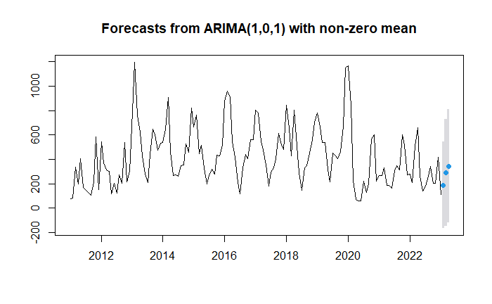

```r
Pronostico=forecast(ModeloArima,level= c(95), h=3)
plot(Pronostico)
```

```r
Pronostico
```

|  | Point Forecast | Lo 95 | Hi 95 |
| --- | --- | --- | --- |
| Feb 2023 | 188.5405 | -166.5181 | 543.5990 |
| Mar 2023 | 289.4107 | -151.2358 | 730.0572 |
| Apr 2023 | 344.9104 | -118.5398 | 808.3607 |

Obteniendo Febrero 2023 = 188.5405, Marzo 2023 = 289.4107 y Abril 2023 = 344.9104